# Single Inverted Pendulum

First we need the model of the single inverted pendulum. Friedland works it mostly out for us in Chapter 2.

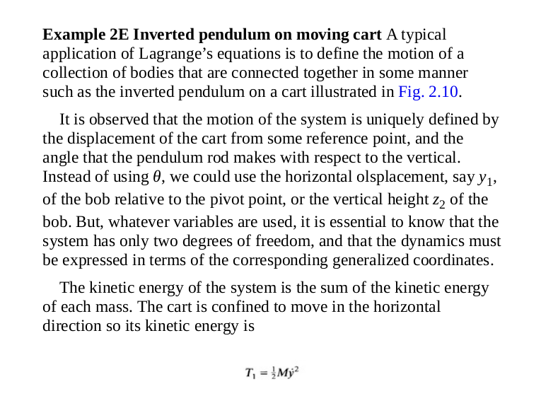

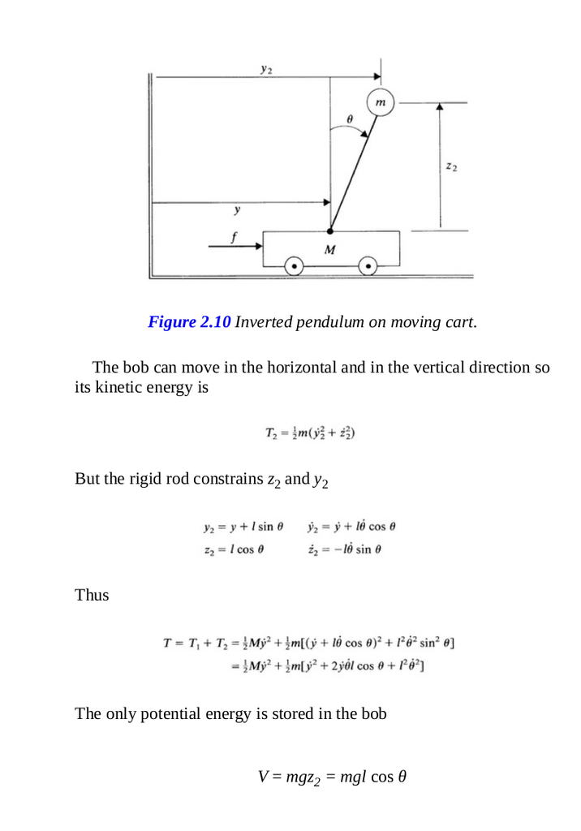

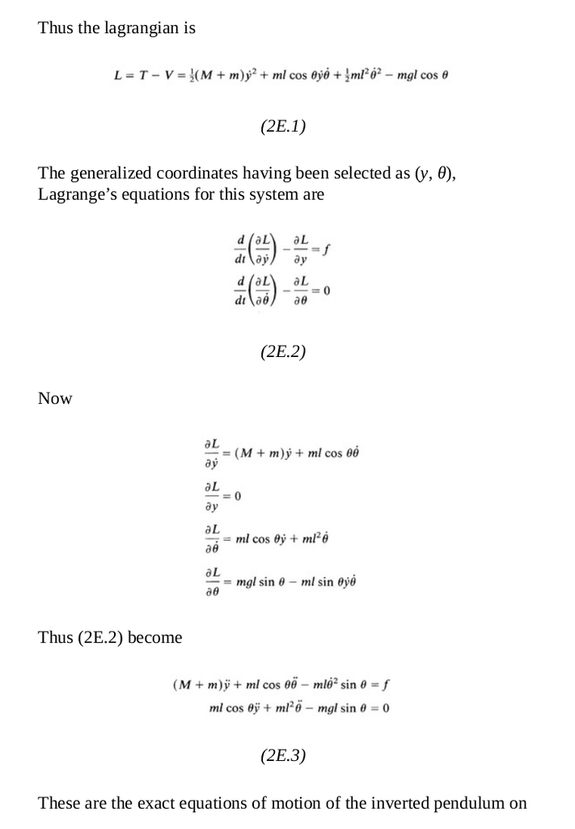

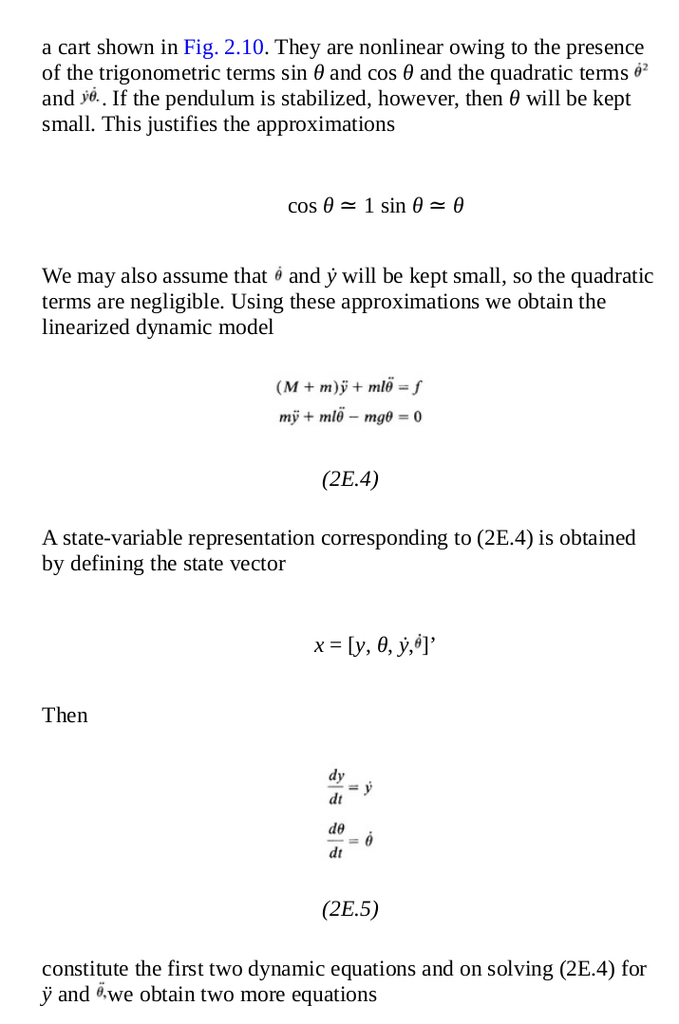

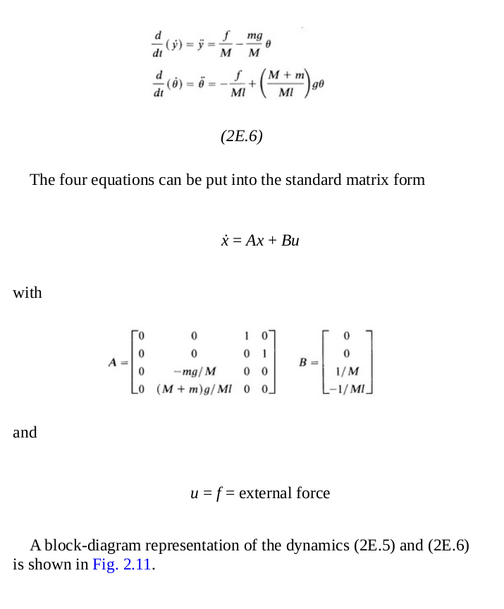

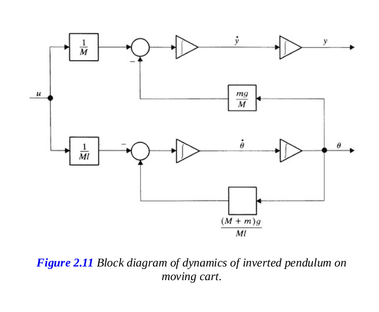

This is with the pendulum driven by a force. In problem 2.2 which you did in Homework 2, we have the model when driven by an electric motor, which is what we have with our hardware. Here is the solution from Joe Dinius.

The cart pendulum equations-of-motion are:

\begin{eqnarray} \ddot y + \frac{mg}{M} \theta &=& \frac{f}{M} \\ \ddot \theta - \frac{M+m}{M \ell} g \theta &=& -\frac{f}{M \ell} \end{eqnarray}

$\tau = rf$, $r$ is the torque-to-linear-force factor. For the electric motor: \begin{eqnarray} \tau &=& -\frac{k^2}{R} \omega + \frac{K}{R}e \\ &=& rf \\ \implies f &=& -\frac{k^2}{Rr} \omega + \frac{K}{Rr}e \end{eqnarray}

The linear acceleration, $\ddot y$, is equal to $\ddot y = r \dot \omega \implies \dot y = r \omega$ by Newton's law. This implies: \begin{eqnarray} f &=& -\frac{k^2}{Rr^2} \dot y + \frac{K}{Rr}e \end{eqnarray}

Plug in $f$ to the first equation: \begin{eqnarray} \ddot y + \frac{mg}{M} \theta &=& -\frac{k^2}{MRr^2} \dot y + \frac{K}{MRr}e \\ \ddot \theta - \frac{M+m}{M \ell} g \theta &=& \frac{k^2}{MRr^2 \ell} \dot y - \frac{K}{MRr \ell}e \end{eqnarray}

Move state derivatives to the LHS: \begin{eqnarray} \ddot y +\frac{k^2}{MRr^2} \dot y + \frac{mg}{M} \theta &=& \frac{K}{MRr}e \\ \ddot \theta - \frac{k^2}{MRr^2 \ell} \dot y - \frac{M+m}{M \ell} g \theta &=& - \frac{K}{MRr \ell}e \end{eqnarray}

The next step is to take this linearized state model and put it into state form. I am going to put the variable $s$ into the equations where $s=1$ for the pendulum up, and $s= -1$ for the pendulum down.

$$\begin{bmatrix} \dot y \\ \dot \theta \\ \ddot {y} \\ \ddot {\theta} \end{bmatrix} = \begin{bmatrix} 0 && 0 && 1 && 0 \\ 0 && 0 && 0 && 1 \\ 0 && -mg/M && -k^2/(MRr^2)&& 0 \\ 0 && s(M+m)g/(Ml) && sk^2/(MRr^2l) && 0 \end{bmatrix} \begin{bmatrix} y \\ \theta \\ \dot{y} \\ \dot {\theta} \end{bmatrix} + \begin{bmatrix} 0 \\ 0 \\ K/(MRr) \\ -sK/(MRrl) \end{bmatrix} e $$

so $$\mathbf A = \begin{bmatrix} 0 && 0 && 1 && 0 \\ 0 && 0 && 0 && 1 \\ 0 && -mg/M && -k^2/(MRr^2)&& 0 \\ 0 && s(M+m)g/(Ml) && sk^2/(MRr^2l) && 0 \end{bmatrix}$$ and $$\mathbf B = \begin{bmatrix} 0 \\ 0 \\ K/(MRr) \\ -sK/(MRrl) \end{bmatrix}$$

For an ideal motor, the torque constant is equal to the back electromotive force constant, so $k = K$. The applied voltage is $e$. The mass of the cart is $M$; the resistance of the motor is $R$; the radius of the wheels (or pulley in our case) is $r$; and the mass of the pendulum is $m$, with $g$ for gravity. For our pendulum, we might need to re-write these in terms of their moments of inertia sometime.

For now let's assume all the states are available, so $$ \mathbf C = \begin{bmatrix} 1 && 0 && 0 && 0 \\ 0 && 1 && 0 && 0 \\ 0 && 0 && 1 && 0 \\ 0 && 0 && 0 && 1 \end{bmatrix}$$

Let's see if our equations are good by simulating the system to see if it works like we expect.

#### Unstable Pendulum (Standing up)

Let's begin with an investigation when the pendulum is standing up, not hanging down. The model allows this with $s=1$.

```
You have an inverted pendulum!
A =

    0.00000    0.00000    1.00000    0.00000
    0.00000    0.00000    0.00000    1.00000
    0.00000   -0.98627   -5.90452    0.00000
    0.00000   33.42499   18.28023    0.00000

B =

   0.00000
   0.00000
   2.13639
  -6.61422

C =

Diagonal Matrix

   1   0   0   0
   0   1   0   0
   0   0   1   0
   0   0   0   1

Eigenvectors and eigenvalues of A:
v =

   1.00000   0.00264  -0.01740  -0.03362
   0.00000  -0.17442   0.13973  -0.21345
   0.00000   0.01489   0.12236   0.15189
   0.00000  -0.98456  -0.98245   0.96449

D =

Diagonal Matrix

   0.00000         0         0         0
         0   5.64481         0         0
         0         0  -7.03082         0
         0         0         0  -4.51851
```

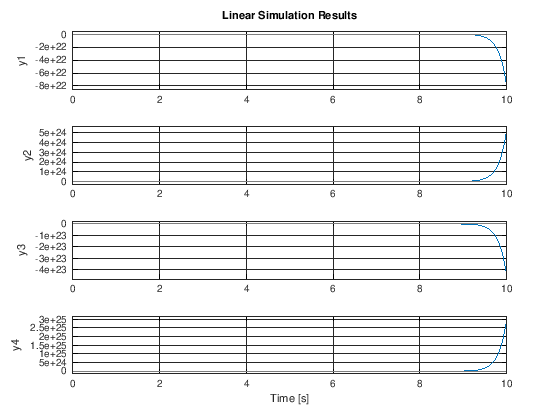

```matlab
clear all; close all;
pkg load control
pkg load signal
graphics_toolkit('gnuplot')

% First set up the parameters for the pendulum.  I will use the values for the WWU pendulum as much as I can.
% M = 0.3163 % Mass of carriage (kg)
% m = 0.0318 % Mass of the long pendulum (kg)
% R = 4.09 % Motor resistance (Ohms)
% r = 0.0254/2  % Pulley radius (meters)
% k = 0.0351 % Torque constant (Nm/A)
% K = 0.0351 % Back emf constant (Vs/rad)
% l = 0.323 % length of the long pendulum rod (meters)
% g = 9.81  % gravity (m/s^2)
% s = 1  %  -1 for hanging down; +1 for up

function [pendsys,A,B,C,D] = setupModel(M=0.3163,m=0.0318,R=4.09,r=0.0254/2,k=0.0351,K=k,l=0.323,g=9.81,s=1)
    if(s==-1)
        disp('Pendulum is hanging down!')
    else
        disp('You have an inverted pendulum!')
    end
    % Now the state model
    A = [[0,0,1,0];[0,0,0,1];[0,-m*g/M,-k^2/(M*R*r^2),0];[0,s*(m+M)*g/(M*l),s*k^2/(M*R*r^2*l),0]];
    B = [0;0;K/(M*R*r);-s*K/(M*R*r*l)];
    C = eye(4);
    D = 0;
    pendsys = ss(A,B,C,D);
endfunction

[pendsys,A,B,C,D] = setupModel();
A
B
C

t = 0:.01:10;
lsim(pendsys,zeros(size(t)),t,[0;pi+0.1;0;0])
disp('Eigenvectors and eigenvalues of A:')
[v,D] = eig(pendsys.a) % Better be all negative for hanging down.
```

Steve Brunton has some interesting things to say about how controllable a system is on his video [here](https://youtu.be/ZNHx62HbKNA?list=PLMrJAkhIeNNR20Mz-VpzgfQs5zrYi085m). I want to check the single pendulum to see how controllable it is. Steve describes how you can tell what directions are more controllable by doing the singular value decomposition of $\mathbf Q$ because Grammian $\mathbf W_t \approx \mathbf {Q Q}^T$.

```matlab
Q = [B, A*B, A^2*B, A^3*B]
Rank_Q = rank(Q)
disp('SVD of Q:')
[U,S,V] = svd(Q,'econ')
```

```
Q =

      0.00000      2.13639    -12.61436     81.00510
      0.00000     -6.61422     39.05374   -451.67356
      2.13639    -12.61436     81.00510   -516.81354
     -6.61422     39.05374   -451.67356   2786.16334

Rank_Q =  4
SVD of Q:
U =

   0.0282043   0.0111817   0.1696492   0.9850374
  -0.1555368  -0.9843002   0.0834251   0.0012588
  -0.1799689  -0.0533000  -0.9669969   0.1723001
   0.9708883  -0.1678902  -0.1708111   0.0035248

S =

Diagonal Matrix

   2907.45011            0            0            0
            0     33.37173            0            0
            0            0      5.42043            0
            0            0            0      0.35021

V =

  -0.0023409   0.0298634  -0.1726989   0.9845191
   0.0141966   0.0194736   0.9847696   0.1721859
  -0.1580536   0.9868328  -0.0115811  -0.0323409
   0.9873257   0.1577655  -0.0164233  -0.0053188
```

The second eigenvector is the unstable one. Note its direction. Then look at the least controllable direction. Note its direction. We don't want them in the same direction. To find the angle between them, we find the dot or inner product between them. They both appear to be unit vectors the way octave calculates them.

```matlab
disp('The inner product between the most uncontrollable direction and the unstable pole is:')
inner_prod_of_unstable_eigenvector_with_difficult_to_control_direction = v(:,2)'*U(:,4)
% disp('Just checking that the eigenvectors are normalized when computed by octave.  Here is the length of one of them.')
% v(:,2)'*v(:,2)
```

```
The inner product between the most uncontrollable direction and the unstable pole is:
inner_prod_of_unstable_eigenvector_with_difficult_to_control_direction =  0.0014756
```

The inner product is small, so that is good! It means they are practically orthogonal. Now let's check to see if we place the poles at the same pole locations, the gain coefficients are all zero.

```matlab
disp('If we leave the poles alone, the gain matrix for this state feedback is:')
gain_for_no_pole_movement = place(A,B,diag(D)) % Should be 0, 0, 0, 0.
```

```
If we leave the poles alone, the gain matrix for this state feedback is:
gain_for_no_pole_movement =

  -0.0000e+00  -6.4342e-16   1.6600e-15  -4.0381e-16
```

### Stable Pendulum Simulation

```
Pendulum is hanging down!

pendsys.a =
            x1       x2       x3       x4
   x1        0        0        1        0
   x2        0        0        0        1
   x3        0  -0.9863   -5.905        0
   x4        0   -33.42   -18.28        0

pendsys.b =
          u1
   x1      0
   x2      0
   x3  2.136
   x4  6.614

pendsys.c =
       x1  x2  x3  x4
   y1   1   0   0   0
   y2   0   1   0   0
   y3   0   0   1   0
   y4   0   0   0   1

pendsys.d =
       u1
   y1   0
   y2   0
   y3   0
   y4   0

Continuous-time model.
A =

    0.00000    0.00000    1.00000    0.00000
    0.00000    0.00000    0.00000    1.00000
    0.00000   -0.98627   -5.90452    0.00000
    0.00000  -33.42499  -18.28023    0.00000

B =

```

[output cut: 37 more lines]

```
   0.00000 + 0.00000i                    0                    0
                    0  -0.13849 + 5.64333i                    0
                    0                    0  -0.13849 - 5.64333i
                    0                    0                    0

 Column 4:

                    0
                    0
                    0
  -5.62754 + 0.00000i

gain_for_same_poles =

  -0.0000e+00  -2.0856e-14  -7.2491e-16  -5.0868e-15
```

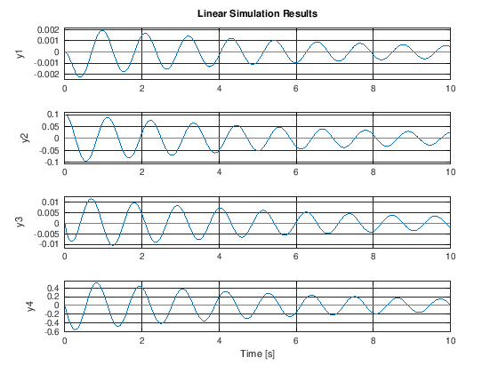

```matlab
s = -1; % Hanging down
[pendsys,A,B,C,D] = setupModel(M=0.3163,m=0.0318,R=4.09,r=0.0254/2,k=0.0351,K=k,l=0.323,g=9.81,s=-1)
lsim(pendsys,zeros(size(t)),t,[0;0.1;0;0])
[v,D] = eig(A)
gain_for_same_poles = place(A,B,diag(D))  % Should be about zeros(4)
```

Remember this is the result of a simulation of a linear model. The question to ask is, "Is this accurate?" To check this out, remember the approximations we made were $cos \theta \approx 1$ and $sin\theta \approx \theta$. For the largest angles we see this works out to be:

```matlab
error_cos = cos(0.1)-1
error_sin = sin(0.1)-0.1
```

```
error_cos = -0.0049958
error_sin = -0.00016658
```

This isn't the only source of error in our simulation. There are at least a couple others. One is due to not knowing the actual parameters very precisely. An approximate error analyisis can be had by looking at the elements in the $A$ matrix to see how they vary as a function of each error. For example if a coefficient, $a_{ij}=f(m,M,r,R,k,K,l)$ then the error is approximately: $$da_{ij} = \frac {\partial a_{ij}} {\partial m} dm+ \frac {\partial a_{ij}} {\partial M} dM+\frac {\partial a_{ij}} {\partial r} dr+\frac {\partial a_{ij}} {\partial R} dR+\frac {\partial a_{ij}} {\partial k} dk+\frac {\partial a_{ij}} {\partial K} dK+\frac {\partial a_{ij}} {\partial l} dl$$

The only reason it damps out is the resistance of the motor windings. We modeled no friction. The underdamped responses (from complex poles) are expected. There could be a damping effect from friction as well. To tell if we should add that to the model, the thing to do is to actually hang the pendulum down, and see if the decay time of the oscillating wave is consistent with what the linear model predicts.

Not changing the pole locations results in a zero gain matrix as expected.

Now let's see if we can make a graphic of the inverted pendulum.

Unfortunately animated octave plots don't seem to work in Jupyter Lab either with gnuplot or fltk graphics toolkits. It only shows the last plot. I put the failed attempt in another notebook in case someday it works. :-)

Let's see if we can change the behavior of the pendulum so it is like it was in honey, dieing out in 1, 2, 3, and 4 seconds. We will place the poles at -1, -2, -3 and -4. Then do the simulation.

```
g =

   0.36988   0.11865  -1.99319   1.26299


pendsys_fb.a =
            x1       x2       x3       x4
   x1        0        0        1        0
   x2        0        0        0        1
   x3  -0.7902    -1.24   -1.646   -2.698
   x4   -2.446   -34.21   -5.097   -8.354

pendsys_fb.b =
       u1
   x1   0
   x2   0
   x3   0
   x4   0

pendsys_fb.c =
       x1  x2  x3  x4
   y1   1   0   0   0
   y2   0   1   0   0
   y3   0   0   1   0
   y4   0   0   0   1

pendsys_fb.d =
       u1
   y1   0
   y2   0
   y3   0
   y4   0

Continuous-time model.
v =

   0.165750   0.258125   0.420738  -0.703688
   0.177060   0.182679   0.151590  -0.069445
  -0.663002  -0.774375  -0.841476   0.703688
  -0.708241  -0.548036  -0.303180   0.069445

D =

Diagonal Matrix

  -4.00000         0         0         0
         0  -3.00000         0         0
         0         0  -2.00000         0
         0         0         0  -1.00000
```

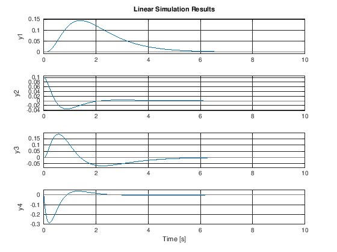

```matlab
g = place(A,B,[-1,-2,-3,-4])
pendsys_fb = ss(A-B*g,zeros(4,1),eye(4),0)
lsim(pendsys_fb,zeros(size(t)),t,[0;0.1;0;0])
[v,D] = eig(A-B*g)
```

Note how the cart moves to keep the natural swinging behavior from happening. The reason it looks a little oscillatory is because some eigenmodes damp out faster and some slower.

It looks like we were successful placing the poles where we wanted them.

Next let's try this in real life with the WWU pendulum. The pendulum motors and shaft angle encoders are controlled by a dedicated digital controller using a Xylinx FPGA that communicates with the user over Ethernet. To control it you use Ralph's code from the ctrlbox.m file below. You have to setup your computer to communicate with the pendulum at address 169.254.0.100. Here are the settings for Ubuntu.

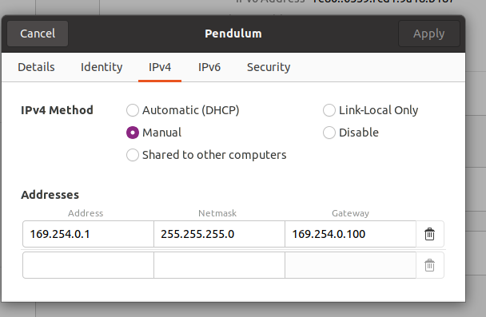

The ctrlbox.m file is shown below.

```matlab
% ctrlbox.m
%
%    Functions for communication with the inverted pendulum
%    ctrlbox interface via ethernet.
1;
%
% ctrlbox_init - initialize connection to ctrlbox
%
function rval = ctrlbox_init()
    global ctrlbox_con;

    ctrlbox_con = socket();
    sinfo = struct("addr","169.254.0.100", "port", 47820);
    rval = connect(ctrlbox_con,sinfo);

    return;
endfunction
%
% ctrlbox_send(cmdval,enable,period)
%  - send command value, enable, and sample period to ctrlbox
%    - cmdval = -32768 to +32767, where 32767=100% of DC bus voltage
%    - enable = 0 or 1
%    - period in usec
%
%  - future: measure time avg of pwm value, shutoff motor
%    if excessive.
function rval = ctrlbox_send(cmdval,enable,period)
    global ctrlbox_con;

    pwm = min(max(cmdval,-32000),32000);  % This keeps it in the interval (-32000, 32000).
    data = [pwm, 0, enable, period];
    send(ctrlbox_con, typecast(int32(data(1:4)),'uint8'));

    rval = 0;
    return;
endfunction
%
% ctrlbox_recv - receive an array of four values from ctrlbox
%
function data = ctrlbox_recv()
    global ctrlbox_con;

    [rdata,len] = recv(ctrlbox_con,16);

    if (len ~= 16)
        fprintf('short data: %d\n', len);  % Check to make sure we got it all.
    end

    data = double(typecast(rdata,'int32'));
    return;

endfunction

%
% ctrlbox_shutdown - shutdown connection to ctrlbox
%
function ctrlbox_shutdown()
    global ctrlbox_con;

    % turn off motor
    send(ctrlbox_con,typecast(int32([0,0,0,0]),'uint8'));

    disconnect(ctrlbox_con);
endfunction
```

Here is a routine to test the pendulum. This helps us understand how things work. You need to install the octave-sockets package if you don't have it already.

```matlab
% To test the controlbox.
% Things discovered (looking from the side the pendulums hang down on):
% With all scale factors positive:
%   Positive um goes to the right.
%   Positive x is to the right.
%   Positive angles are clockwise.
pkg load control sockets;
um = 10;
% ctrlbox;            % load ctrlbox comm functions  We already have it above.
T = 1/130;
go1 = 0;
Maxpos = 0.22;              % Max carriage travel +- 0.22 m
Maxvoltage = 20;
Vmax = 20;                  % H-bridge max drive voltage (pwm), V
rodstart = 1*pi/180;        % Angle starting limit, rad
dispscale = 0.02;           % Input knob; displacement per revolution, m/rev
rd = 0.0254/2;              % m			Drive pulley radius
% Set up encoder scale factors
anglescale = 2*pi/4096;
carriagescale = 2*pi*rd/4096;
knobscale = dispscale/1024;
readscale = [anglescale anglescale carriagescale knobscale];
writescale = 32767/Vmax;
kmax = 50;
k = 0

try
    ctrlbox_init();
    disp('finished init');

    % send sample period
    period = 1000000.*T;
    ctrlbox_send(0,0,period);
    disp('finished send');
    fflush(stdout);

% Start up trigger loop.  This appears to be take the place of hitting enter.
    while ~go1
        %data = readscale.*double(pnet(conthandle,'read',4,'int32','native'));
        data = ctrlbox_recv().*readscale;
        display (data);  % See the data as you make it.
        fflush(stdout);
        if (abs(data(1)+pi) < rodstart) &&  (abs(data(2)+pi) < rodstart)
            go1 = 1;
            disp('CONTROL TRIGGERED!')
            fflush(stdout);
        end
    end

    while (k <= kmax)
       ctrlbox_send(um*writescale, 1, 0);   % Positive um goes to the right.
       fprintf("Just sent motor voltage.\n");
       fflush(stdout);
       if (abs(data(3)) > Maxpos) || (abs(um) > Maxvoltage)     % out-of-range
            um;  % Print this to see how far out of range it is.
            go = 0;
            % Write control output
            ctrlbox_send(0, 1, 0);
            fprintf("We are out of range!\n");
            fflush(stdout);
            k = k + 1;
      end
  end
catch
    % if something failed, display error and loop count
    disp(lasterror.message);
    fflush(stdout);
end
```

```
k = 0
connect failed with error 113 (No route to host)
```

Here is part of an example I think used to run the pendulum.

```matlab
scale = [-rd*2*pi/4096  -2*pi/4096 -0.05/250];  % Check these.
pause;

Trun = 10  % 10 seconds
T = 1/200;
cnt = Trun/T;

try
    ctrlbox_init();

    disp('finished init');

    % send sample period
    period = 1000000./T;

    ctrlbox_send(0,0,period);

    disp('finished send');

while (1)
    x = 1:cnt;
    tic;
    for c=1:cnt
        % read encoder values
        rdata = ctrlbox_recv();
        %xhat(:,c+1)=T*(Ahat*xhat(:,c)-Bhat*G*xhat(:,c)+K*[rd*rdata(3).*scale(1);rdata(1)*scale(2)-pi])+xhat(:,c);

        % pwm generation
        %pwm = ((-G*xhat(:,c+1))*32768)/20;

        % write pwm valuesm and enable motor
        ctrlbox_send(pwm, 1, 0);

        % force matlab to check for interrupts and flush event queue
        drawnow;

        % save data
        % store(c,:) = [rdata(1).*scale(2),rdata(3).*scale(1),xhat(:,c+1)(2),xhat(:,c+1)(4),0];
        store_sc(c,:) = [rd*rdata(3).*scale(1), rdata(1)*scale(2)-pi];
        store(c,:) = [rdata, pwm];
    end
    runtime = toc;
    fprintf('transactions=%d seconds=%d transactions/sec=%f\n', c, runtime, c/runtime);
    drawnow;
end
catch
    % if something failed, display error and loop count
    fprintf('c=%d\n',c);
    disp(lasterror.message);
end

% disable motor and disconnect
ctrlbox_shutdown();

t = 0:T:Trun;
plot(t,store_sc(:,1),t,store_sc(:,2))
```

```
Trun =  10
error: 'c' undefined near line 41 column 22
error: 'store_sc' undefined near line 1 column 8
```

## State Feedback With the Unstable Pendulum

Let's now go back to the unstable pendulum and try to place the poles where we want them. We will need to use a numerical approximation for the derivative to get the state variables for $\dot y$ and $\dot \theta$ for the actual pendulum, but first, let's simulate state feedback.